# Introduction

### Business Objective

The goal of this project is to build a **venue recommender** for *meetup group orgnizers*. On the one hand, this app could help *organizers* explore wonderful *venue* options that were liked by other fellows who have hosted similar events. On the other hand, this app could also serve as great advertising resorces for business *venues* and assist them to target potential clients.

### Dataset

The dataset was fetched from the [*Meetup API*](https://www.meetup.com/meetup_api/) utilizing a [python API client](https://pypi.org/project/meetup-api/). In particular, I first identified the Meetup groups with more than 100 members in the top 30 largest [US cities](https://en.wikipedia.org/wiki/List_of_United_States_cities_by_population) and then gathered the meetup details associated with these groups between 2010 and 2018.

The fetched raw dataset is around 10 GB.

### Solutions

To tackle these challenges, I will buld a **hybrid recommender system** which combined *content,* demographic *and* collaborative filtering*.

- **demographic filtering** all recommendations were limited to the same city of the query.
- **content filtering** documents of meetup group descriptions were used to measure the similarity among groups, and then venues that have hosted events for similar groups were recommended. In particular, a Recurrent Neuralnet work was first trained to classify meetup group categories, the output of the dense layer was used as the feature for measure group similarity.
- **collaborative filtering** (ongoing) collaborative filtering models with alternating least squares (ALS) optimization were trained. The interaction matrix is between meetup groups and venues, with the number of hosted events as implicit feedback.

```python
%matplotlib inline
import viz
```

### Explore Venues

Before introducing the recommender system, let's first use Boston as an example to explore the venues that host socializing, career-business, tech, and music related meetups. In the following plot, each dot represents one venue location. The color of the dot depicts the meetup category and the size is propotional to the number of meetups that have been hosted in this location.

This plot indicates some interesting patterns of venue geographic distributions.

- tech meetup venues center mostly around MIT and downtown Boston
- business meetup venues overlap a lot with tech venues
- venues that host socializing meetups are more dispersed than other categories

```python
viz.explore_venues()
```

[interactive chart not shown]

# Content Filtering

The content-based filtering approach depends on the similarity of *group descriptions* (a document of meetup group introduction). In other words, the recommender system first identifies other similar meetup groups and then recommend the venues that have hosted meetup events for these groups.

#### meetup category classifier

I first built a meetup category classifier for group descriptions. The assumption is that if we could successfully classify the group category based on the features extracted from description documents, we could also use these features to measure the group similarities with confident. To achieve better performance, I compared eight different models (four machine learning models and four deep learning models).

Text cleaning was first conducted to remove stop words and non-word characters.

For *machine learning models*, I extracted the TFIDF (term frequency–inverse document frequency) with chi-square feature selection (top 10000 features). Then, Multinomial Naïve Bayes Classifier ([MNB](https://scikit-learn.org/stable/modules/generated/sklearn.naive_bayes.MultinomialNB.html)), Linear Support Vector Machine Classifier ([SVC](https://scikit-learn.org/stable/modules/svm.html)), Random Forest Classifier ([RFC](https://scikit-learn.org/shttps://scikit-learn.org/stable/modules/generated/sklearn.ensemble.ExtraTreesClassifier.htmltable/modules/generated/sklearn.ensemble.RandomForestClassifier.html)), and Etra Tree Classifier(ETC) were trained on 80% of the data and evaluated on the rest split.

For *deep-learning models*, I employed pre-trained [GloVe](https://nlp.stanford.edu/projects/glove/) word vectors as the embedding layer and evaluated the following four structures (common for sequence classification) with cross-validation: Multiple Layer Perception Network (MLP), 1D convolutional Network ([Con1D](https://keras.io/layers/convolutional/#conv1d)), Gated recurrent unit Network ([GRU](https://keras.io/layers/recurrent/#cudnngru)), and a combination of Con1D and GRU.

To benchmark the performance of these models, I used the [F1-score](https://scikit-learn.org/stable/modules/generated/sklearn.metrics.f1_score.html), since it combines both precision and recall. In particular, I examined the category classification F1-score on the top 5, 10, 15, and 20 categories with most number of groups. Five models with highest F1-scores are shown here.

Since Recurrent Network utilizing GRU has given descent performance to classify meetup categories with group descriptions. I used the output of the last dense layer as the features to measure the 'content-based' similarity among different meetup groups.

```python
viz.classification_report()
```

[interactive chart not shown]

#### feature visualization

Though both SVC and RNN with GRU have the best classification results. It is quite difficult to visualize import features. In constrast, MNB is a super easy model, which also has pretty good performance. We could examine the feature importance of this model. Here are some examples of the important features (keywords) for different meetup group categories.

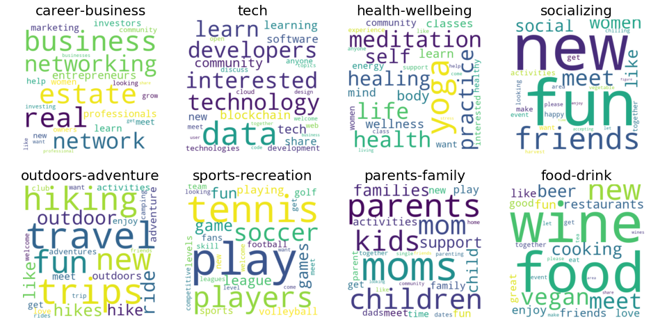

```python
viz.plot_key_features()
```